# An Analysis of Commonly Held Fan Beliefs About Referees

Nathaniel Vaduthala

[Website](https://nvaduthala3.github.io/)

# Project Goals

In this project, I will attempt to see if commonly held beliefs about referees amongst fans of the NBA are true. In particular, these beliefs include opinions such as "star players always receive preferential treatment when it comes to foul calls", "in the NBA Playoffs, the referees call less fouls", and "some referees are fair, while others are biased."

# Datasets

In order to develop a complete understanding of every question, I will be using multiple datasets to answer these questions. The first of the datasets will be the one regarding players' average statistics per game along with teams' total statistics, hosted by [Basketball Reference](https://https://www.basketball-reference.com/leagues/NBA_2022_per_minute.html). This data is collected by Sportradar, the official statistics partner of the NBA, and so this dataset is trustworthy. Using this dataset, I will attempt to answer the question "is it true that NBA referees call less fouls in the Playoffs than in the Regular Season?" In particular, I will be looking at the average number of foul calls per game in the Regular Season, and compare it with the average number of foul calls per game in the Playoffs from 2012 to 2022. Along with this, I will attempt to answer the question "is it true that star players receive preferential treatment?". I will specifically be looking at foul calls in the Regular Season. In order to answer this question, I will determine if there is a relationship between average fouls per game and different single value metrics. However, one issue with this analysis is that it is an estimate. We cannot determine exactly how many foul calls a player received or didn't receive that were in their favor. To mitigate this issue, we turn to our second data set.

The second data set I will be using is the [NBA's Officiating Last 2 Minutes](https://raw.githubusercontent.com/atlhawksfanatic/L2M/master/1-tidy/L2M/L2M-stats-nba.csv) dataset. This dataset contains the list of incorrect calls performed by referees in the last two minutes of a game where the score differential was at most three points. I will add that although this data originates from the NBA, I was able to find it in tidy data form. It was cleaned up into this format by GitHub user atlhawksfanatic. I have reviewed what they did to clean up the data into tidy form, and I do not see any issues, and so I view this dataset as also being trustworthy. I will be using this dataset to help answer the question "is it true that star players receive preferential treatment?" The strength of this dataset comes from the fact that we can tell which players received favorable foul calls and how many they received, and so using this dataset, along with the Basketball Reference dataset, we can develop a more accurate understanding if star players do receive preferential treatment.

I will also be using this dataset to answer the question "are there some referees that can be considered 'good' or 'bad'?" I define a *good referee*, to be "a referee that has called fouls in a manner that provides no evidence of negative statistical bias", and a *bad referee* to be "a referee that cannot be considered good." By negative statistical bias, I mean if a referee has consistently called incorrect calls in the last two minutes. I will be using this dataset to see how many correct and incorrect calls each referee made in the last two minutes of a close game on average. However, while this is helpful because we can see exactly how many incorrect calls each referee made in the last two minutes of a close game, this information does not tell us about the other 46 minutes of gameplay. Any extrapolation made just from this data will not be accurate. In order to develop a better understanding of the innacurate calls made throughout the entire game, we will be using the third dataset.

The third data set I will be using is one regarding referee statistics provided by [Basketball Reference](https://www.basketball-reference.com/referees/2022_register.html). This data set provides information about the average number of foul calls each referee made in the 2021-22 NBA season and the average number of foul calls they made on the home and away teams. Using this data, I will be comparing the statistics of foul calls made by each referee to the average and determine if there are any outliers. This will help us develop a better overall understanding if there are "good" and "bad" referees.

Along with this, I will be using multiple other datasets provided by [Basketball Reference](https://www.basketball-reference.com/playoffs/series.html) to determine if there is enough statistical evidence to state that referees call possible Playoff extension games in a different manner than the average Playoff game. I will be looking at Playoff series starting from the 2010-11 NBA Playoffs up to the 2021-22 Playoffs. I will not be going back beyond this, as the NBA is an ever changing league and so all Playoffs before 2010-11 are too different to be used to look at the recent NBA.

# Collaboration Plan

Because I am a graduate student, I will be working alone on this project. From now until October 22, I will be cleaning the data sets and putting them into tidy data format if necessary. From October 22 to November 10, I plan on performing exploratory data analysis in order to begin developing conclusions. I will primarily be using Google Colab on this project.

# ETL (Extraction, Transform, and Load)

Currently, I have loaded two of the three datasets that I plan on using. I have loaded the datatset from Basketball Reference regarding players' average statistics and the dataset from the NBA's Last 2 Minutes report. Currently, I have focused on cleaning and tidying the dataset regarding players' averages.

# Relation Between Single-Value Player Metrics and Personal Foul Call Amounts

Before we can even determine if there is a relationship between a player's stardom and the number of foul calls they receive, we first need to define what a "star player" is. To do so, I will be using common single-value player metrics. These metrics attempt to provide a single number that quantifies how talented a player is. The single-value player metrics I will be using are Win Shares per 48 (WS/48), and Value Over Replacement Plyer (VORP). Notably, I am not using Player Efficiency Rating (PER) here, as it seems to be no longer used in basketball analytics.

The higher these values are, the more of a star the corresponding player is. Therefore, we will attempt to see if there is a relationship between these values and the average number of foul calls per game. I imported one data set from Basketball Reference that included the average number of personal foul calls a player received, along with another data set from Basketball Reference that was primarily focused on single-value player metrics.

```python
# Import data for BBall Ref

import pandas as pd
import numpy as np

url_br_2021_per36 = 'https://raw.githubusercontent.com/NVaduthala3/cmps-6160-project/main/bball_ref_2021_per36.csv' # '2021' here means 2021-22 season
df_br_2021_per36 = pd.read_csv(url_br_2021_per36) # DataFrame containing players' average stats

url_br_2021_adv = 'https://raw.githubusercontent.com/NVaduthala3/cmps-6160-project/main/bball_ref_2021_advanced.csv'
df_br_2021_adv = pd.read_csv(url_br_2021_adv) # DateFrame containing single-value metrics

df_br_2021_per36.head()
```

|  | Rk | Player | Pos | Age | Tm | G | GS | MP | FG | FGA | ... | ORB | DRB | TRB | AST | STL | BLK | TOV | PF | PTS | Player-additional |
| --- | --- | --- | --- | --- | --- | --- | --- | --- | --- | --- | --- | --- | --- | --- | --- | --- | --- | --- | --- | --- | --- |
| 0 | 1 | Precious Achiuwa | C | 22 | TOR | 73 | 28 | 1725 | 5.5 | 12.6 | ... | 3.0 | 6.8 | 9.9 | 1.7 | 0.8 | 0.9 | 1.8 | 3.2 | 13.9 | achiupr01 |
| 1 | 2 | Steven Adams | C | 28 | MEM | 76 | 75 | 1999 | 3.8 | 6.9 | ... | 6.3 | 7.4 | 13.7 | 4.6 | 1.2 | 1.1 | 2.1 | 2.8 | 9.5 | adamsst01 |
| 2 | 3 | Bam Adebayo | C | 24 | MIA | 56 | 56 | 1825 | 8.0 | 14.4 | ... | 2.7 | 8.4 | 11.1 | 3.7 | 1.6 | 0.9 | 2.9 | 3.4 | 21.1 | adebaba01 |
| 3 | 4 | Santi Aldama | PF | 21 | MEM | 32 | 0 | 360 | 5.3 | 13.2 | ... | 3.3 | 5.4 | 8.7 | 2.1 | 0.6 | 1.0 | 1.6 | 3.6 | 13.2 | aldamsa01 |
| 4 | 5 | LaMarcus Aldridge | C | 36 | BRK | 47 | 12 | 1050 | 8.6 | 15.7 | ... | 2.5 | 6.3 | 8.8 | 1.4 | 0.5 | 1.6 | 1.5 | 2.7 | 20.8 | aldrila01 |

5 rows × 30 columns

After importing the data for the 2021-22 NBA season, it is necessary now to remove of any data points that cannot provide us any value. In order to take into account that different players play a different number of minutes, and therefore will most likely have a higher number of foul calls, I imported in the data set that proportionately normalized the players' average statistics to if they had played 36 minutes every game, df_br_2021_per36. However, in the case of players that had played either less than 15 minutes on average or had played less than 35 games, we cannot make any normalization, as they have not played enough to make a realistic extrapolation. Therefore, I want to remove these players from df_br_2021_per36.

But before I can do that, I have to first create a new column that described how many minutes per game a player played on average. This is because the dataset containing the players' average statistics did not contain this information. But, it did contain the total number of minutes played ('MP') and the total number of games played ('G'), and so with this, I was able to find the average number of minutes played ('MPG').

I also force every value that was greater than 6 in the "Personal Fouls" column of df_br_2021_per36 to be equal to 6, as a player cannot receive more than 6 fouls in an NBA game.

After performing this, it is also necessary to perform an inner join onto DataFrame containing information regarding the players' average statistics, df_br_2021, adv, and df_br_2021_per36, as df-br_2021_adv does not contain any information about average fouls called on the player.

```python
# clean up data for BBall Ref

df_br_2021_per36['MPG'] = df_br_2021_per36.apply(lambda row: row['MP'] / row['G'], axis = 1) # calculate minutes per game
df_br_2021_per36 = df_br_2021_per36.drop(df_br_2021_per36[(df_br_2021_per36['MPG'] < 15) | (df_br_2021_per36['G'] < 35)].index) # remove players with insufficient games/min playes
df_br_2021_per36.loc[df_br_2021_per36['PF'] > 6, 'PF'] = 6 # impossible to have more than 6 fouls

df_br_2021_adv_pf = df_br_2021_adv.merge(df_br_2021_per36, how = 'inner') # add personal fouls column onto advanced stats dataframe

df_br_2021_adv_pf.head()
```

|  | Rk | Player | Pos | Age | Tm | G | MP | PER | TS% | 3PAr | ... | ORB | DRB | TRB | AST | STL | BLK | TOV | PF | PTS | MPG |
| --- | --- | --- | --- | --- | --- | --- | --- | --- | --- | --- | --- | --- | --- | --- | --- | --- | --- | --- | --- | --- | --- |
| 0 | 1 | Precious Achiuwa | C | 22 | TOR | 73 | 1725 | 12.7 | 0.503 | 0.259 | ... | 3.0 | 6.8 | 9.9 | 1.7 | 0.8 | 0.9 | 1.8 | 3.2 | 13.9 | 23.630137 |
| 1 | 2 | Steven Adams | C | 28 | MEM | 76 | 1999 | 17.6 | 0.560 | 0.003 | ... | 6.3 | 7.4 | 13.7 | 4.6 | 1.2 | 1.1 | 2.1 | 2.8 | 9.5 | 26.302632 |
| 2 | 3 | Bam Adebayo | C | 24 | MIA | 56 | 1825 | 21.8 | 0.608 | 0.008 | ... | 2.7 | 8.4 | 11.1 | 3.7 | 1.6 | 0.9 | 2.9 | 3.4 | 21.1 | 32.589286 |
| 3 | 5 | LaMarcus Aldridge | C | 36 | BRK | 47 | 1050 | 19.6 | 0.604 | 0.100 | ... | 2.5 | 6.3 | 8.8 | 1.4 | 0.5 | 1.6 | 1.5 | 2.7 | 20.8 | 22.340426 |
| 4 | 6 | Nickeil Alexander-Walker | SG | 23 | TOT | 65 | 1466 | 10.5 | 0.475 | 0.497 | ... | 0.9 | 3.7 | 4.6 | 3.8 | 1.1 | 0.6 | 2.3 | 2.5 | 17.0 | 22.553846 |

5 rows × 53 columns

From here, we can see some preliminary results.

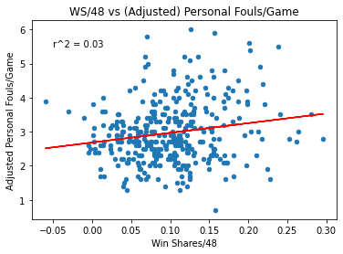

```python
# Plot WS/48 vs PF
import matplotlib.pyplot as plt
from scipy import stats

df_br_2021_adv_pf.plot.scatter(x = 'WS/48', y = 'PF')

result = stats.linregress(x = df_br_2021_adv_pf['WS/48'], y = df_br_2021_adv_pf['PF'])

plt.plot(df_br_2021_adv_pf['WS/48'], result.intercept + result.slope*(df_br_2021_adv_pf['WS/48']), 'r')
plt.text(-0.05, 5.5, 'r^2 = %0.2f' % (result.rvalue) ** 2)
plt.title('WS/48 vs (Adjusted) Personal Fouls/Game')
plt.xlabel('Win Shares/48')
plt.ylabel('Adjusted Personal Fouls/Game')
```

We can see from the graph that there does not appear to be any relationship between an increased Win Shares per 48--and therefore increased stardom--and the average number of personal fouls called on the player. Although there is a positive correlation, the *r-squared* value is small enough that we cannot make a claim of there being any relation.

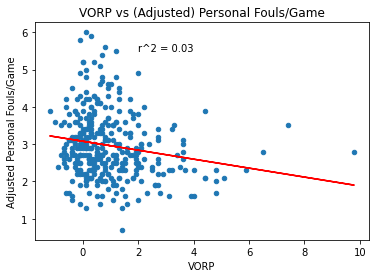

```python
df_br_2021_adv_pf.plot.scatter(x = 'VORP', y = 'PF')

result2 = stats.linregress(x = df_br_2021_adv_pf['VORP'], y = df_br_2021_adv_pf['PF'])

plt.plot(df_br_2021_adv_pf['VORP'], result2.intercept + result2.slope*(df_br_2021_adv_pf['VORP']), 'r')
plt.text(2, 5.5, 'r^2 = %0.2f' % (result2.rvalue) ** 2)
plt.title('VORP vs (Adjusted) Personal Fouls/Game')
plt.xlabel('VORP')
plt.ylabel('Adjusted Personal Fouls/Game')
```

In a similar manner as in the first graph, we cannot conclude any definitive relationship between the stardom of a player and the number of foul call received in a game. In this case, the correlation is negative, but the *r-squared* value is once again too small for us to state a relationship.

# Calculate Actual Number of Favorable Calls Made

Now, I will look at the actual favorable calls made, and see if there is a relationship between the single-value player metrics and the number of favorable calls made. In particular, what I will be counting is the *net number of favorable calls*. In the NBA's Last 2 Minutes dataset, there are columns that outlines which player was disadvantaged and which player committed the foul. As a result, I can count how many times every player was either at an advantageous position in a foul call or at a a disadvantageous position. By assigning the value 1 to an advantageous position, and a -1 to a disadvantageous position, I will count up all the situations that a player was in, and this will be their net number of favorable calls. From here, I will then see if there is a relationship between this variable and the single-value player metrics.

Before I can do this, I must first remove all the rows that contain data not in the 2021-22 season.

```python
# Import data from NBA L2M, provided by atlhawksfanatic

url_l2m = 'https://raw.githubusercontent.com/atlhawksfanatic/L2M/master/1-tidy/L2M/L2M-stats-nba.csv'
df_l2m = pd.read_csv(url_l2m)
df_l2m = df_l2m.drop((df_l2m[(df_l2m['season'] != 2022) | (df_l2m['playoff'] == True)].index)) #'2022' here means 2021-22 season, and only want Regular Season
df_l2m.head()
```

|  | period | time | call_type | committing | disadvantaged | decision | comments | game_details | page | file | ... | committing_side | disadvantaged_min | disadvantaged_team | disadvantaged_side | type2 | time_min | time_sec | time2 | season | playoff |
| --- | --- | --- | --- | --- | --- | --- | --- | --- | --- | --- | --- | --- | --- | --- | --- | --- | --- | --- | --- | --- | --- |
| 54498 | Q4 | 01:33.8 | Violation: Delay of Game | Aaron Henry | Aaron Henry | IC | Called + No Infraction | NaN | NaN | 0012100023.csv | ... | home | 7.366667 | PHI | home | DELAY OF GAME | 1 | 33.8 | 1.563333 | 2022 | False |
| 54499 | Q4 | 00:53.2 | Violation: Delay of Game | Aaron Henry | Aaron Henry | CC | Called + Infraction | NaN | NaN | 0012100023.csv | ... | home | 7.366667 | PHI | home | DELAY OF GAME | 0 | 53.2 | 0.886667 | 2022 | False |
| 54500 | Q4 | 00:30.9 | Violation: Delay of Game | Aaron Henry | Shaquille Harrison | CNC | No Called + No Infraction | NaN | NaN | 0012100023.csv | ... | home | 7.366667 | PHI | home | DELAY OF GAME | 0 | 30.9 | 0.515000 | 2022 | False |
| 54501 | Q4 | 00:23.3 | Turnover: Traveling | Jaden Springer | Raptors | INC | No Called + Infraction | NaN | NaN | 0012100023.csv | ... | home | NaN | TOR | away | TRAVELING | 0 | 23.3 | 0.388333 | 2022 | False |
| 54502 | Q4 | 01:45 | Foul: Shooting | Obi Toppin | Jayson Tatum | CNC | Toppin (NY) makes clean contact with the ball ... | NaN | NaN | 0022100005.csv | ... | home | 44.650000 | BOS | away | SHOOTING | 1 | 45.0 | 1.750000 | 2022 | False |

5 rows × 64 columns

```python
df_l2m = df_l2m.dropna(subset=['call_type', 'committing', 'disadvantaged', # Remove NaN values in columns we care about
                               'decision'])

df_l2m = df_l2m[df_l2m['committing'] != df_l2m['disadvantaged']] # Avoid possible repeats

# remove calls that are not fouls, like delay of game or a turnover
df_l2m = df_l2m[df_l2m['call_type'].str.contains('Foul', case=False)]

# removes all possible team names, except the Trail Blazers
mask_commit = df_l2m['committing'].str.count(' ').ge(1)
df_l2m = df_l2m[mask_commit]

mask_disadv = df_l2m['disadvantaged'].str.count(' ').ge(1)
df_l2m = df_l2m[mask_disadv]

df_l2m = df_l2m[(df_l2m['committing'] != 'Trail Blazers') & (df_l2m['disadvantaged'] != 'Trail Blazers')]
```

Now, we say that a player received a *favorable call* if they are called committing a foul and the decision is seen as an incorrect non-call, or if they are the disadvantaged player and received an incorrect call. We say that a player received an *unfavorable call* if they are called committing a foul and the decision is seen as an incorrect call, or if they are the disadvantaged player and the decision is seen as an incorrect non-call. All other cases can be considered to be a neutral (correct) call and so they will automatically have a value of 0.

However, we must also take into account the fact that different players will play different amounts of time in the last two minutes and so the number of foul situations they were involved in will also differ, and therefore it may not be fair to directly compare the net number of favorable calls between players. In order to mitigate this issue, we will instead look at the *net number of favorable calls per 100 possessions*. In order to find this value, we will first find the net number of favorable calls, and then we will find the number of possessions that a player was involved in a foul call. We will then divide the net number of favorable calls by the number of possessions in order to find the net number of favorable calls per possion, and then multiply this value by 100.

```python
df_fav = pd.DataFrame()
df_fav = pd.DataFrame(pd.concat([df_l2m['committing'], df_l2m['disadvantaged']], ignore_index = True).unique())
df_fav['favorable count'] = ' '
df_fav['unfavorable count'] = ' '
df_fav['possession count'] = ' '
df_fav.columns = ['Player', 'favorable count', 'unfavorable count', 'possession count']
df_fav = df_fav.set_index('Player')

for player in df_fav.index:
  fav_count = df_l2m.loc[
    (df_l2m['committing'].eq(player) & df_l2m['decision'].eq('INC')) |
    (df_l2m['disadvantaged'].eq(player) & df_l2m['decision'].eq('IC'))
  ]
  unfav_count = df_l2m.loc[
    (df_l2m['committing'].eq(player) & df_l2m['decision'].eq('IC')) |
    (df_l2m['disadvantaged'].eq(player) & df_l2m['decision'].eq('INC'))
  ]
  poss_count = df_l2m['committing'].tolist().count(player) + df_l2m['disadvantaged'].tolist().count(player)
  df_fav.at[player, 'possession count'] = poss_count
  df_fav.at[player, 'favorable count'] = len(fav_count)
  df_fav.at[player, 'unfavorable count'] = len(unfav_count)

df_fav['net favorable count'] = df_fav['favorable count'] - df_fav['unfavorable count']
df_fav['net fav count per 100 poss'] = df_fav['net favorable count'] / df_fav['possession count'] * 100

df_fav = df_fav.reset_index()

df_fav.shape
```

```
(435, 6)
```

We also need to consider the fact that some players have not been involved in enough possesions to where we can say that their net number of favorable calls per 100 possessions is a fair extrapolation. To fix this issue, we will drop all the players that have beenn involved in less than 5 possesions. The reason we use 5 is because if we go any lower, then we simply no longer will be fixing the problem, but if we go any higher, then there is a chance that we start cutting off meaningful data. The choice of having 5 as the baseline is also justified by the fact that the 25% percentile is 7 and the 50% percentile is 22, and so the vast majority of the data here is above the 5 benchmark.

```python
pd.to_numeric(df_fav['possession count'], errors = 'coerce').describe()
```

```
count    435.000000
mean      32.611494
std       31.512463
min        1.000000
25%        7.000000
50%       22.000000
75%       52.000000
max      173.000000
Name: possession count, dtype: float64
```

```python
df_fav = df_fav[df_fav['possession count'] > 4]
```

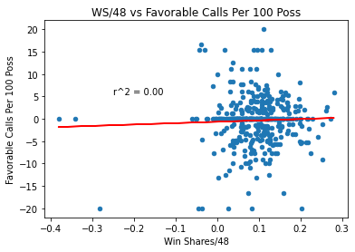

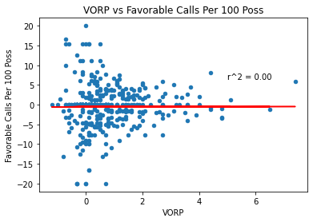

```python
df_br_2021_adv_pf_fav = df_br_2021_adv.merge(df_fav, how = 'inner')

df_br_2021_adv_pf_fav.plot.scatter(x = 'WS/48', y = 'net fav count per 100 poss')

result = stats.linregress(x = df_br_2021_adv_pf_fav['WS/48'], y = pd.to_numeric(df_br_2021_adv_pf_fav['net fav count per 100 poss']))

plt.plot(df_br_2021_adv_pf_fav['WS/48'], result.intercept + result.slope*(df_br_2021_adv_pf_fav['WS/48']), 'r')
plt.text(-0.25, 5.5, 'r^2 = %0.2f' % (result.rvalue) ** 2)
plt.title('WS/48 vs Favorable Calls Per 100 Poss')
plt.xlabel('Win Shares/48')
plt.ylabel('Favorable Calls Per 100 Poss')

df_br_2021_adv_pf_fav.plot.scatter(x = 'VORP', y = 'net fav count per 100 poss')

result = stats.linregress(x = df_br_2021_adv_pf_fav['VORP'], y = pd.to_numeric(df_br_2021_adv_pf_fav['net fav count per 100 poss']))

plt.plot(df_br_2021_adv_pf_fav['VORP'], result.intercept + result.slope*(df_br_2021_adv_pf_fav['WS/48']), 'r')
plt.text(5, 6.5, 'r^2 = %0.2f' % (result.rvalue) ** 2)
plt.title('VORP vs Favorable Calls Per 100 Poss')
plt.xlabel('VORP')
plt.ylabel('Favorable Calls Per 100 Poss')
```

We can see that there seems to be no relationship between the net number of favorable calls per 100 possesions and VORP, and the net number of favorable calls per 100 possesions and Win Shares per 48.

# Conclusion Regarding The Relationship Between Star Players and Foul Calls

Based upon our analysis, we can conclude that there seems to be no evidence indicating that there exists a relationship between if a player is a star player and if they receive more beneficial foul calls.

# Determine if Some Refereees Have Evidence of Statistical Bias

Our next goal is to determine if the calls made by some referees show evidence of negative statistical bias, which would then make them be considered *bad*. We will first use the Last 2 Minutes Dataset to determine the average number of the *net correct calls* made by the referees, which is defined to be the diffeence between the number of correct calls and the number of incorrect calls, and from there we will determine if there are any referees that can be considered statistical outliers. We will then determine the average number of correct calls made and also see if there are any statistical outliers.

To find the average number of net correct calls made, we first need to find all the individual games that have their data in the DataSet, and then from there find the number of correct and incorrect foul calls that happened within those games. Finally, we will sum up all the incorrect foul calls and then divide this value by the number of games.

```python
# Import data from NBA L2M, provided by atlhawksfanatic

url_l2m = 'https://raw.githubusercontent.com/atlhawksfanatic/L2M/master/1-tidy/L2M/L2M-stats-nba.csv'
df_l2m_ref = pd.read_csv(url_l2m)
df_l2m_ref = df_l2m_ref.drop((df_l2m_ref[(df_l2m_ref['season'] != 2022) | (df_l2m_ref['playoff'] == True)].index)) #'2022' here means 2021-22 season, and only want Regular Season
df_l2m_ref['game_id'].head()

# separate DataFrame into individual games

df_games_list = []
for id in df_l2m_ref['game_id'].unique():
  df_games_list.append(df_l2m_ref[df_l2m_ref['game_id'] ==id])

df_game_info = pd.DataFrame()
df_game_info['game id'] = df_l2m_ref['game_id'].unique()
df_game_info['correct calls'] = ' '
df_game_info['incorrect calls'] = ' '
df_game_info['net correct calls'] = ' '
df_game_info['ref 1'] = ' '
df_game_info['ref 2'] = ' '
df_game_info['ref 3'] = ' '

# calculate calls made in each game

call_list = [pd.DataFrame(game['decision'].value_counts()) for game in df_games_list]
call_list = [call.reset_index() for call in call_list]
for call in call_list:
  call.columns = ['type', 'count']

for call in call_list:
  call_type = ['IC', 'INC', 'CC', 'CNC']
  for call_t in call_type:
    if (call_t not in call.values):
      call.loc[len(call.index)] = [call_t, 0]

for call in call_list:
  call.set_index('type', inplace=True)

# add ref names to dataframe

correct_call_list = [call.loc['CNC', 'count'] + call.loc['CC', 'count'] for call in call_list]
incorrect_call_list = [call.loc['IC', 'count'] + call.loc['INC', 'count'] for call in call_list]
ref_1_list = [game[['OFFICIAL_1']].loc[game.first_valid_index(), 'OFFICIAL_1'] for game in df_games_list]
ref_2_list = [game[['OFFICIAL_2']].loc[game.first_valid_index(), 'OFFICIAL_2'] for game in df_games_list]
ref_3_list = [game[['OFFICIAL_3']].loc[game.first_valid_index(), 'OFFICIAL_3'] for game in df_games_list]

df_game_info['correct calls'] = correct_call_list
df_game_info['incorrect calls'] = incorrect_call_list
df_game_info['ref 1'] = ref_1_list
df_game_info['ref 2'] = ref_2_list
df_game_info['ref 3'] = ref_3_list
df_game_info['net correct calls'] = df_game_info['correct calls'] - df_game_info['incorrect calls']

df_game_info.head()
```

|  | game id | correct calls | incorrect calls | net correct calls | ref 1 | ref 2 | ref 3 |
| --- | --- | --- | --- | --- | --- | --- | --- |
| 0 | 12100023.0 | 2 | 2 | 0 | Ray Acosta | Evan Scott | Mark Lindsay |
| 1 | 22100005.0 | 34 | 2 | 32 | Scott Foster | Lauren Holtkamp | Ed Malloy |
| 2 | 22100004.0 | 22 | 1 | 21 | Derek Richardson | Mousa Dagher | Tyler Ford |
| 3 | 22100007.0 | 15 | 0 | 15 | Michael Smith | John Conley | Kevin Scott |
| 4 | 22100003.0 | 33 | 3 | 30 | Rodney Mott | Scott Wall | Nate Green |

What we will now do is associate each referee with the number of net correct calls made in the games they oversaw, along with their average net correct calls made per 2 minutes. We find this latter value in an attempt to take into account the fact that some referees oversee more games than others.

However, it should be mentioned that this analysis is flawed. With this method, I will be "sharing the blame." It could be the case that a referee did not actually make many, or any for that matter, incorrect calls, but they will still be labelled as doing so if they were working with a referee that made incorrect calls. To try and mitigate this issue, I will be dividing the number of correct and incorrect calls associated with each referee by 3. Thus, I am making the assumption that each ref is equally likely to make an incorrect call. This is a faulty assumption of course. So far, I have not found a dataset that specifically describes which referee called a specific foul call, but I will still try and find new ways of fixing this issue.

```python
df_ref_info = pd.DataFrame()
df_ref_info['name'] = ' '
df_ref_info['correct calls'] = ' '
df_ref_info['incorrect calls'] = ' '
df_ref_info['net correct calls'] = ' '

df_ref_info['name'] = pd.DataFrame(pd.concat([df_game_info['ref 1'], df_game_info['ref 2'], df_game_info['ref 3']], ignore_index = True).unique())
ref_info_list = [df_game_info.loc[(df_game_info['ref 1'] == name) | (df_game_info['ref 2'] == name) | (df_game_info['ref 3'] == name)] for name in list(df_ref_info['name'])]

cor_call_list = [ref['correct calls'].sum() for ref in ref_info_list]
df_ref_info['correct calls'] = np.divide(cor_call_list, 3)

incor_call_list = [ref['incorrect calls'].sum() for ref in ref_info_list]
df_ref_info['incorrect calls'] = np.divide(incor_call_list, 3)

net_cor_call_list = [ref['net correct calls'].sum() for ref in ref_info_list]
df_ref_info['net correct calls'] = np.divide(net_cor_call_list, 3)

df_ref_info['average net correct calls per 2 min'] = np.divide([ref['net correct calls'].sum() / len(ref) for ref in ref_info_list], 3)
df_ref_info['difference of individual avg NCC/2 min and overall'] = ( df_ref_info['average net correct calls per 2 min']
                                                                    - (df_ref_info['average net correct calls per 2 min'].sum() / len(df_ref_info)))

df_ref_info.head()
```

|  | name | correct calls | incorrect calls | net correct calls | average net correct calls per 2 min | difference of individual avg NCC/2 min and overall |
| --- | --- | --- | --- | --- | --- | --- |
| 0 | Ray Acosta | 113.000000 | 12.333333 | 100.666667 | 4.575758 | -1.027148 |
| 1 | Scott Foster | 105.666667 | 7.000000 | 98.666667 | 6.166667 | 0.563761 |
| 2 | Derek Richardson | 133.333333 | 7.333333 | 126.000000 | 6.631579 | 1.028673 |
| 3 | Michael Smith | 134.000000 | 11.000000 | 123.000000 | 5.347826 | -0.255080 |
| 4 | Rodney Mott | 79.000000 | 5.333333 | 73.666667 | 6.696970 | 1.094064 |

We now remove all referees that have less than 10 minutes reffed in this dataset. We remove them because there is not sufficient data to make any claims about possible bias.

```python
df_ref_info['minutes reffed'] = [2*len(ref) for ref in ref_info_list]

df_ref_info = df_ref_info[df_ref_info['minutes reffed'] > 9]

df_ref_info.head()
```

|  | name | correct calls | incorrect calls | net correct calls | average net correct calls per 2 min | difference of individual avg NCC/2 min and overall | minutes reffed |
| --- | --- | --- | --- | --- | --- | --- | --- |
| 0 | Ray Acosta | 113.000000 | 12.333333 | 100.666667 | 4.575758 | -1.027148 | 44 |
| 1 | Scott Foster | 105.666667 | 7.000000 | 98.666667 | 6.166667 | 0.563761 | 32 |
| 2 | Derek Richardson | 133.333333 | 7.333333 | 126.000000 | 6.631579 | 1.028673 | 38 |
| 3 | Michael Smith | 134.000000 | 11.000000 | 123.000000 | 5.347826 | -0.255080 | 46 |
| 4 | Rodney Mott | 79.000000 | 5.333333 | 73.666667 | 6.696970 | 1.094064 | 22 |

Let us now visualize how this data looks through the use of a scatter plot.

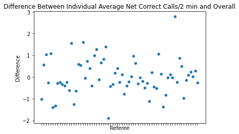

```python
df_ref_info.plot.scatter(x = 'name', y = 'difference of individual avg NCC/2 min and overall')

plt.title('Difference Between Individual Average Net Correct Calls/2 min and Overall')
plt.tick_params(
    axis='x',
    which='both',
    bottom=True,
    top=False,
    labelbottom=False)
plt.xlabel('Referee')
plt.ylabel('Difference')
```